# Cluster Analysis on Crime Data

Sriram B

22 July 2018

**NOTE** Before starting this activity please remember to clear your environment.

```r
rm(list = ls(all=TRUE))
```

# Agenda

- Read the dataset
- Data pre-processing
- Explore the dataset
- Hierarchical Clustering
  - Cluster Visualizion and Evaluation
- Kmeans Clustering
  - Cluster Visualizion and Evaluation

# Problem Description

- In the following Unsupervised Learning activity, we try to cluster Crime demographics of US state (50 states) wise data.

# Reading & Understanding the Data

- Make sure the dataset is located in your current working directory

```r
# Use the setwd() function to get to the directory where the data is present
crime_data <- read.csv('crime_data.csv', header = T)
```

- Use the str(), summary() functions to get a feel for the dataset.

```r
str(crime_data)
```

```
## 'data.frame':    50 obs. of  5 variables:
##  $ State   : Factor w/ 50 levels "Alabama","Alaska",..: 1 2 3 4 5 6 7 8 9 10 ...
##  $ Murder  : num  13.2 10 8.1 8.8 9 7.9 3.3 5.9 15.4 17.4 ...
##  $ Assault : int  236 263 294 190 276 204 110 238 335 211 ...
##  $ UrbanPop: int  58 48 80 50 91 78 77 72 80 60 ...
##  $ Rape    : num  21.2 44.5 31 19.5 40.6 38.7 11.1 15.8 31.9 25.8 ...
```

```r
summary(crime_data)
```

```
##         State        Murder          Assault         UrbanPop
##  Alabama   : 1   Min.   : 0.800   Min.   : 45.0   Min.   :32.00
##  Alaska    : 1   1st Qu.: 4.075   1st Qu.:109.0   1st Qu.:54.50
##  Arizona   : 1   Median : 7.250   Median :159.0   Median :66.00
##  Arkansas  : 1   Mean   : 7.788   Mean   :170.8   Mean   :65.54
##  California: 1   3rd Qu.:11.250   3rd Qu.:249.0   3rd Qu.:77.75
##  Colorado  : 1   Max.   :17.400   Max.   :337.0   Max.   :91.00
##  (Other)   :44
##       Rape
##  Min.   : 7.30
##  1st Qu.:15.07
##  Median :20.10
##  Mean   :21.23
##  3rd Qu.:26.18
##  Max.   :46.00
##
```

- The dataset has 50 observations of 5 variables
- The column/variable names’ are self explanatory

```r
#See the head and tail of the dataframe
head(crime_data)
```

```
##        State Murder Assault UrbanPop Rape
## 1    Alabama   13.2     236       58 21.2
## 2     Alaska   10.0     263       48 44.5
## 3    Arizona    8.1     294       80 31.0
## 4   Arkansas    8.8     190       50 19.5
## 5 California    9.0     276       91 40.6
## 6   Colorado    7.9     204       78 38.7
```

```r
tail(crime_data)
```

```
##            State Murder Assault UrbanPop Rape
## 45       Vermont    2.2      48       32 11.2
## 46      Virginia    8.5     156       63 20.7
## 47    Washington    4.0     145       73 26.2
## 48 West Virginia    5.7      81       39  9.3
## 49     Wisconsin    2.6      53       66 10.8
## 50       Wyoming    6.8     161       60 15.6
```

# Data Pre-processing

- Identify the categorical and numerical attributes appropriately

```r
#Store all column names in variable called 'attr'
attr <- colnames(crime_data)
str(attr)
```

```
##  chr [1:5] "State" "Murder" "Assault" "UrbanPop" "Rape"
```

```r
#Store all categorical attributes in 'cat_Attr'
cat_attr <- "State"

#Now, how to find the numerical attributes?
num_attr <- setdiff(attr, c(cat_attr, "State"))
num_attr
```

```
## [1] "Murder"   "Assault"  "UrbanPop" "Rape"
```

```r
crime_data$state <- as.factor(as.character(crime_data$State))

#Now see the structure of the dataframe
str(crime_data)
```

```
## 'data.frame':    50 obs. of  6 variables:
##  $ State   : Factor w/ 50 levels "Alabama","Alaska",..: 1 2 3 4 5 6 7 8 9 10 ...
##  $ Murder  : num  13.2 10 8.1 8.8 9 7.9 3.3 5.9 15.4 17.4 ...
##  $ Assault : int  236 263 294 190 276 204 110 238 335 211 ...
##  $ UrbanPop: int  58 48 80 50 91 78 77 72 80 60 ...
##  $ Rape    : num  21.2 44.5 31 19.5 40.6 38.7 11.1 15.8 31.9 25.8 ...
##  $ state   : Factor w/ 50 levels "Alabama","Alaska",..: 1 2 3 4 5 6 7 8 9 10 ...
```

- Convert the names of the States to the row names, as this will later help us in visualising the clusters

```r
rownames(crime_data) <- crime_data$State
```

- Drop the ‘State’ column as it is now just redundant information

```r
#Make a copy of the dataframe for later use (mixed attributes)
crime_data_copy <- crime_data
crime_data <- crime_data[, -c(colnames(crime_data) %in% ("State"))]
# (or)
crime_data$State <- NULL
```

- There are no Categorical Attributes, so we need not ‘dummify’ any column
- The data must be scaled, before measuring any type of distance metric as the variables with higher ranges will significantly influence the distance

```r
crime_data[, num_attr] <- scale(crime_data[,num_attr], center = T, scale = T)
```

# Data exploration

- We can use the fviz_dist() function from the factoextra package, to visualize the distances between the observations

```r
#install.packages("factoextra")
# if(!require(devtools)) install.packages("devtools")
# devtools::install_github("kassambara/factoextra")

library(factoextra)
# Use the get_dist() function from the factoexrtra to calculate inter-observation distances
distance <- get_dist(crime_data)
```

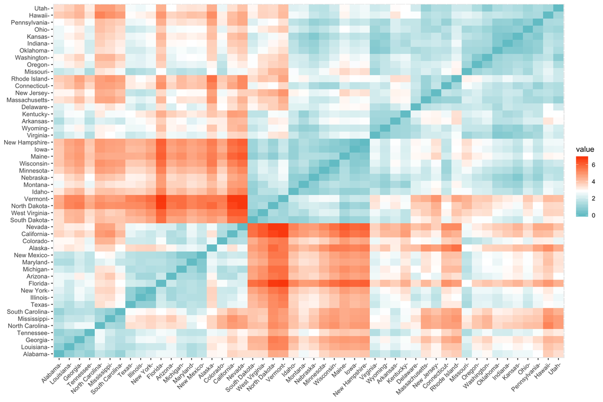

```r
# The fviz_dist() function plots a visual representation of the inter-observation distances
fviz_dist(distance, gradient = list(low = "#00AFBB", mid = "white", high = "#FC4E07"))
```

```r
# The gradient argument, helps us define the color range for the distance scale
```